# Una estimacion de los salarios de la NBA

## 7. Analisis de los residuos del modelo

### 7.1. Normalidad

Con los siguientes dos graficos podemos observar cual el la distribucion de los residuos de nuestro modelo

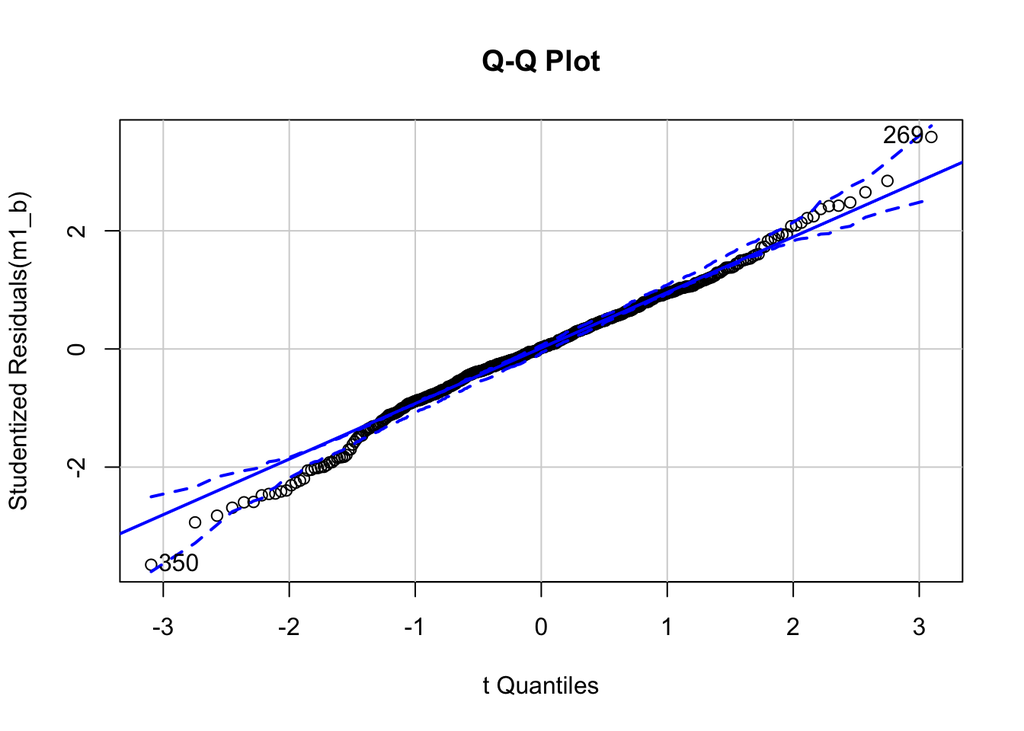

```
## [1] 269 350
```

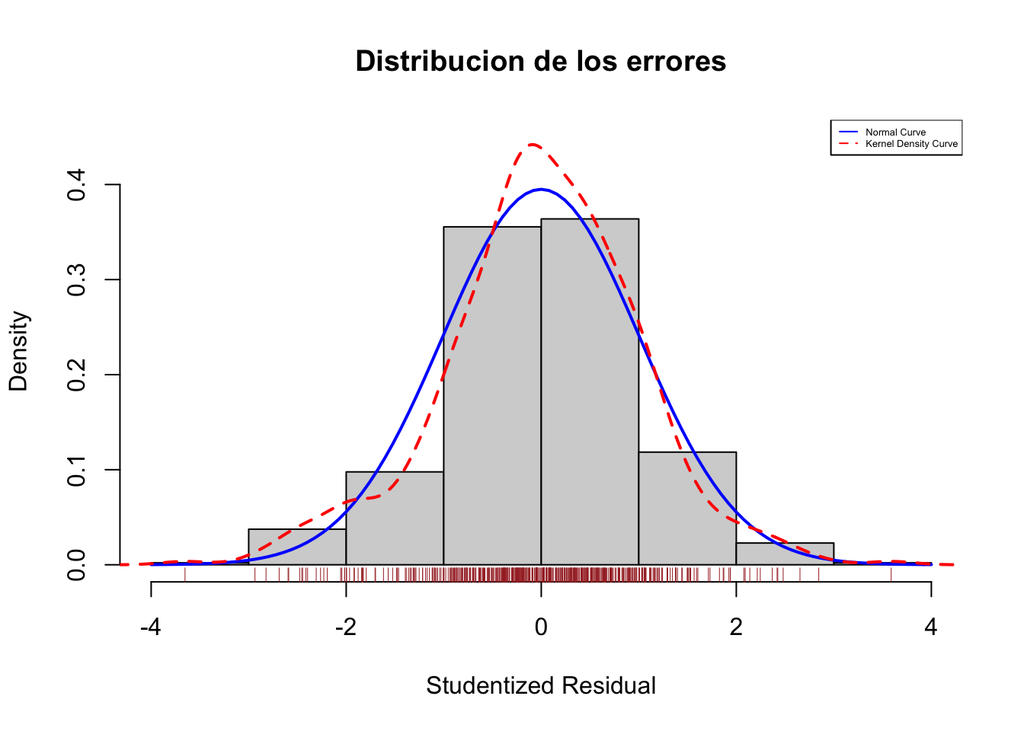

Para confirma la normalidad de los residuos realizaremos el constraste de Shapiro-Wilk. Obtenemos un Pvalor = 0,004, inferior que el 5%, por lo que rechazamos la Hipotesis Nula de normalidad de los residuos.

```r
shapiro.test(resid(m1_b))
```

```
##
##  Shapiro-Wilk normality test
##
## data:  resid(m1_b)
## W = 0.99091, p-value = 0.004684
```

### 7.2. Homoscedasticidad

Con un Pvalor menor al 5% en el constraste de Breusch-Pagan rechazmos la hipotesis nula de que los resiudos tienen varinza constante

```r
ncvTest(m1_b)
```

```
## Non-constant Variance Score Test
## Variance formula: ~ fitted.values
## Chisquare = 52.5075, Df = 1, p = 4.2861e-13
```

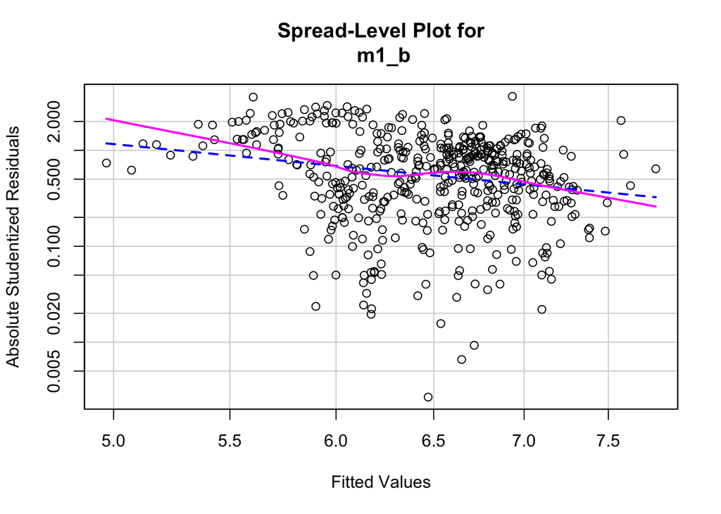

```
##
## Suggested power transformation:  3.867926
```

```r
spreadLevelPlot(m1_b)
```

### 7.3. Contraste global

Con la realizacion del test global observamos que nuestro modelo pasa el test de simetria y el de homoscedasticidad, a pesar de lo que nos digo el constraste de Breusch-Pagan, pero en general es un modelo con problemas estadistico en su utilizacion para explicar la variable dependiente.

```r
gvlma(m1_b)
```

```
##
## Call:
## lm(formula = log(Salary, base = 10) ~ NBA_DraftNumber + Age +
##     MP + PER + TSp + TRBp + ASTp + TOVp + USGp + DWS + WSd48 +
##     OBPM + BPM, data = nba)
##
## Coefficients:
##     (Intercept)  NBA_DraftNumber              Age               MP
##       4.5286117       -0.0098659        0.0437968        0.0003902
##             PER              TSp             TRBp             ASTp
##      -0.0653310        1.2023677        0.0275924        0.0068926
##            TOVp             USGp              DWS            WSd48
##      -0.0090857        0.0302956       -0.0883894        2.2707356
##            OBPM              BPM
##      -0.0402456        0.0423008
##
##
## ASSESSMENT OF THE LINEAR MODEL ASSUMPTIONS
## USING THE GLOBAL TEST ON 4 DEGREES-OF-FREEDOM:
## Level of Significance =  0.05
##
## Call:
##  gvlma(x = m1_b)
##
##                       Value   p-value                   Decision
## Global Stat        32.72560 1.359e-06 Assumptions NOT satisfied!
## Skewness            3.57633 5.861e-02    Assumptions acceptable.
## Kurtosis            8.37409 3.806e-03 Assumptions NOT satisfied!
## Link Function      20.68987 5.400e-06 Assumptions NOT satisfied!
## Heteroscedasticity  0.08531 7.702e-01    Assumptions acceptable.
```

## 8. Preddiccion

En el ultimo apartado observaremos como de fiable es nuestro modelo a la hora de la prediccion.

Lo primero calcularemos la desviacion tipica de los residuos de nuestro modelo ya que es un buen indicador a la hora de predecir y observamos que es relativamente baja

```r
sd(resid(m1_b))
```

```
## [1] 0.4320049
```

Acontinuacion construiremos una tabla con tres columnas, el valor real del salario, el valor que predice nuestro modelo y la diferencia de ambos en valor absoluto

```
## # A tibble: 481 x 3
##    LogSal predLogSalary difSalary
##     <dbl>         <dbl>     <dbl>
##  1   5.91          5.90    0.0102
##  2   6.54          6.82    0.277
##  3   7.09          7.20    0.112
##  4   6.51          6.35    0.158
##  5   6.49          6.45    0.0402
##  6   6.12          6.42    0.306
##  7   4.87          5.94    1.07
##  8   4.66          5.51    0.847
##  9   7.08          7.10    0.0217
## 10   6.16          6.18    0.0195
## # … with 471 more rows
```

Para finalizar este trabajo calcularemos la media y la desviacion tipica de la diferencia del salario real y del salario estimado para comprobar en cuanto se equivoca nuestro modelo

```r
mean(pre_salary$difSalary)
```

```
## [1] 0.3308638
```

```r
sd(pre_salary$difSalary)
```

```
## [1] 0.2773613
```